# House Selling Prices

### Validation

There is little drop in the validation $R^2$ showing that the model is robust to new data.

```r
## create validation table
# Compute R-squared for each validation

  # Get y-hat for each model on new data.
  yht <- predict(lm.train, newdata=mytest)


  # Compute y-bar
  ybar <- mean(mytest$SalePrice) #Yi is given by Ynew from the new sample of data

  # Compute SSTO
  SSTO <- sum( (mytest$SalePrice - ybar)^2 )

  # Compute SSE for each model using y - yhat
  SSEt <- sum( (mytest$SalePrice - yht)^2 )


  # Compute R-squared for each
  rst <- 1 - SSEt/SSTO


  # Compute adjusted R-squared for each
  n <- length(mytest$SalePrice) #sample size
  pt <- length(coef(lm.train)) #num. parameters in model

  rsta <- 1 - (n-1)/(n-pt)*SSEt/SSTO



my_output_table2 <- data.frame(Model = c("My Model"), `Original R2` = c(summary(lm.train)$r.squared), `Orig. Adj. R-squared` = c(summary(lm.train)$adj.r.squared), `Validation R-squared` = c(rst), `Validation Adj. R^2` = c(rsta))

colnames(my_output_table2) <- c("Model", "Original $R^2$", "Original Adj. $R^2$", "Validation $R^2$", "Validation Adj. $R^2$")

knitr::kable(my_output_table2, escape=TRUE, digits=4)
```

| Model | Original $R^2$ | Original Adj. $R^2$ | Validation $R^2$ | Validation Adj. $R^2$ |
| --- | --- | --- | --- | --- |
| My Model | 0.853 | 0.8502 | 0.8402 | 0.8325 |

### Diagnostics

There are limitations to this analysis because the data violates some assumptions of multiple linear regression. Linearity seems ok because the red loess curve is quite flat, but constant variance appears violated. The normality of the residuals is also violated, appearing heavy-tailed in the Q-Q plot. Observing the plots mapping Cook’s distance, there are multiple data points with high leverage on the data that are potentially skewing results. No patterns appear in the residuals vs order plot, however, so this assumption is met.

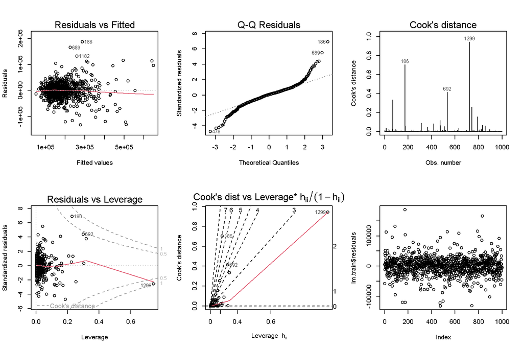

```r
par(mfrow=c(2,3))
plot(lm.train, which = c(1,2,4,5, 6))
plot(lm.train$residuals)
```